# titanic

## O Danych

Dane o pasażerach Titanica

Zbiór danych zawiera informacje o pasażerach RMS Titanic, który zatonął 15 kwietnia 1912 roku po zderzeniu z górą lodową. Dane obejmują takie atrybuty jak klasa podróży, wiek, płeć, liczba rodzeństwa/małżonków na pokładzie, liczba rodziców/dzieci na pokładzie, cena biletu oraz miejsce zaokrętowania.

Zbiór zawiera także informację o tym, czy pasażer przeżył katastrofę.

Titanic przewoził ponad 2,200 osób, z czego ponad 1,500 zginęło, co czyni tę katastrofę jedną z najbardziej tragicznych w historii morskiej.

Kolumny:

- **pclass** - Klasa biletu
- **survived** - Czy pasażer przeżył katastrofę
- **name** - Imię i nazwisko pasażera
- **sex** - Płeć pasażera
- **age** - Wiek pasażera
- **sibsp** - Liczba rodzeństwa/małżonków na pokładzie
- **parch** - Liczba rodziców/dzieci na pokładzie
- **ticket** - Numer biletu
- **fare** - Cena biletu
- **cabin** - Numer kabiny
- **embarked** - Port, w którym pasażer wszedł na pokład (C = Cherbourg, Q = Queenstown, S = Southampton)
- **boat** - Numer łodzi ratunkowej
- **body** - Numer ciała (jeśli pasażer nie przeżył i ciało zostało odnalezione)
- **home.dest** - Miejsce docelowe

```python
import pandas as pd
import seaborn as sns
import matplotlib.pyplot as plt
```

```python
df = pd.read_csv('26__titanic.csv', sep=",")
df
```

|  | pclass | survived | name | sex | age | sibsp | parch | ticket | fare | cabin | embarked | boat | body | home.dest |
| --- | --- | --- | --- | --- | --- | --- | --- | --- | --- | --- | --- | --- | --- | --- |
| 0 | 1.0 | 1.0 | Allen, Miss. Elisabeth Walton | female | 29.0000 | 0.0 | 0.0 | 24160 | 211.3375 | B5 | S | 2 | NaN | St Louis, MO |
| 1 | 1.0 | 1.0 | Allison, Master. Hudson Trevor | male | 0.9167 | 1.0 | 2.0 | 113781 | 151.5500 | C22 C26 | S | 11 | NaN | Montreal, PQ / Chesterville, ON |
| 2 | 1.0 | 0.0 | Allison, Miss. Helen Loraine | female | 2.0000 | 1.0 | 2.0 | 113781 | 151.5500 | C22 C26 | S | NaN | NaN | Montreal, PQ / Chesterville, ON |
| 3 | 1.0 | 0.0 | Allison, Mr. Hudson Joshua Creighton | male | 30.0000 | 1.0 | 2.0 | 113781 | 151.5500 | C22 C26 | S | NaN | 135.0 | Montreal, PQ / Chesterville, ON |
| 4 | 1.0 | 0.0 | Allison, Mrs. Hudson J C (Bessie Waldo Daniels) | female | 25.0000 | 1.0 | 2.0 | 113781 | 151.5500 | C22 C26 | S | NaN | NaN | Montreal, PQ / Chesterville, ON |
| ... | ... | ... | ... | ... | ... | ... | ... | ... | ... | ... | ... | ... | ... | ... |
| 1305 | 3.0 | 0.0 | Zabour, Miss. Thamine | female | NaN | 1.0 | 0.0 | 2665 | 14.4542 | NaN | C | NaN | NaN | NaN |
| 1306 | 3.0 | 0.0 | Zakarian, Mr. Mapriededer | male | 26.5000 | 0.0 | 0.0 | 2656 | 7.2250 | NaN | C | NaN | 304.0 | NaN |
| 1307 | 3.0 | 0.0 | Zakarian, Mr. Ortin | male | 27.0000 | 0.0 | 0.0 | 2670 | 7.2250 | NaN | C | NaN | NaN | NaN |
| 1308 | 3.0 | 0.0 | Zimmerman, Mr. Leo | male | 29.0000 | 0.0 | 0.0 | 315082 | 7.8750 | NaN | S | NaN | NaN | NaN |
| 1309 | NaN | NaN | NaN | NaN | NaN | NaN | NaN | NaN | NaN | NaN | NaN | NaN | NaN | NaN |

1310 rows × 14 columns

# Wykonujemy analizę w odpowiedniość do EDA

### 1. Ogólny przegląd danych

```python
# Wybieramy 10 randomowych wierszy z dataframe
random_rows = df.sample(n=10)
random_rows
```

|  | pclass | survived | name | sex | age | sibsp | parch | ticket | fare | cabin | embarked | boat | body | home.dest |
| --- | --- | --- | --- | --- | --- | --- | --- | --- | --- | --- | --- | --- | --- | --- |
| 162 | 1.0 | 0.0 | Holverson, Mr. Alexander Oskar | male | 42.0 | 1.0 | 0.0 | 113789 | 52.0000 | NaN | S | NaN | 38.0 | New York, NY |
| 1191 | 3.0 | 0.0 | Saundercock, Mr. William Henry | male | 20.0 | 0.0 | 0.0 | A/5. 2151 | 8.0500 | NaN | S | NaN | NaN | NaN |
| 357 | 2.0 | 0.0 | Byles, Rev. Thomas Roussel Davids | male | 42.0 | 0.0 | 0.0 | 244310 | 13.0000 | NaN | S | NaN | NaN | London |
| 829 | 3.0 | 0.0 | Goodwin, Miss. Lillian Amy | female | 16.0 | 5.0 | 2.0 | CA 2144 | 46.9000 | NaN | S | NaN | NaN | Wiltshire, England Niagara Falls, NY |
| 1026 | 3.0 | 1.0 | Moor, Mrs. (Beila) | female | 27.0 | 0.0 | 1.0 | 392096 | 12.4750 | E121 | S | 14 | NaN | NaN |
| 271 | 1.0 | 1.0 | Snyder, Mr. John Pillsbury | male | 24.0 | 1.0 | 0.0 | 21228 | 82.2667 | B45 | S | 7 | NaN | Minneapolis, MN |
| 615 | 3.0 | 0.0 | Alhomaki, Mr. Ilmari Rudolf | male | 20.0 | 0.0 | 0.0 | SOTON/O2 3101287 | 7.9250 | NaN | S | NaN | NaN | Salo, Finland Astoria, OR |
| 533 | 2.0 | 1.0 | Phillips, Miss. Alice Frances Louisa | female | 21.0 | 0.0 | 1.0 | S.O./P.P. 2 | 21.0000 | NaN | S | 12 | NaN | Ilfracombe, Devon |
| 1254 | 3.0 | 1.0 | Tornquist, Mr. William Henry | male | 25.0 | 0.0 | 0.0 | LINE | 0.0000 | NaN | S | 15 | NaN | NaN |
| 228 | 1.0 | 0.0 | Penasco y Castellana, Mr. Victor de Satode | male | 18.0 | 1.0 | 0.0 | PC 17758 | 108.9000 | C65 | C | NaN | NaN | Madrid, Spain |

*Dane nie zawierają podejrzanych wartości, ale zwracamy uwagę na to że są komórki, gdzie są brakujące wartości, a w kolumnie 'name' czasami mamy w nawiasach inne imię.*

```python
# Zobaczymy sobie jeszcze 10 rzędów od góry i od dołu
df.head(10)
```

|  | pclass | survived | name | sex | age | sibsp | parch | ticket | fare | cabin | embarked | boat | body | home.dest |
| --- | --- | --- | --- | --- | --- | --- | --- | --- | --- | --- | --- | --- | --- | --- |
| 0 | 1.0 | 1.0 | Allen, Miss. Elisabeth Walton | female | 29.0000 | 0.0 | 0.0 | 24160 | 211.3375 | B5 | S | 2 | NaN | St Louis, MO |
| 1 | 1.0 | 1.0 | Allison, Master. Hudson Trevor | male | 0.9167 | 1.0 | 2.0 | 113781 | 151.5500 | C22 C26 | S | 11 | NaN | Montreal, PQ / Chesterville, ON |
| 2 | 1.0 | 0.0 | Allison, Miss. Helen Loraine | female | 2.0000 | 1.0 | 2.0 | 113781 | 151.5500 | C22 C26 | S | NaN | NaN | Montreal, PQ / Chesterville, ON |
| 3 | 1.0 | 0.0 | Allison, Mr. Hudson Joshua Creighton | male | 30.0000 | 1.0 | 2.0 | 113781 | 151.5500 | C22 C26 | S | NaN | 135.0 | Montreal, PQ / Chesterville, ON |
| 4 | 1.0 | 0.0 | Allison, Mrs. Hudson J C (Bessie Waldo Daniels) | female | 25.0000 | 1.0 | 2.0 | 113781 | 151.5500 | C22 C26 | S | NaN | NaN | Montreal, PQ / Chesterville, ON |
| 5 | 1.0 | 1.0 | Anderson, Mr. Harry | male | 48.0000 | 0.0 | 0.0 | 19952 | 26.5500 | E12 | S | 3 | NaN | New York, NY |
| 6 | 1.0 | 1.0 | Andrews, Miss. Kornelia Theodosia | female | 63.0000 | 1.0 | 0.0 | 13502 | 77.9583 | D7 | S | 10 | NaN | Hudson, NY |
| 7 | 1.0 | 0.0 | Andrews, Mr. Thomas Jr | male | 39.0000 | 0.0 | 0.0 | 112050 | 0.0000 | A36 | S | NaN | NaN | Belfast, NI |
| 8 | 1.0 | 1.0 | Appleton, Mrs. Edward Dale (Charlotte Lamson) | female | 53.0000 | 2.0 | 0.0 | 11769 | 51.4792 | C101 | S | D | NaN | Bayside, Queens, NY |
| 9 | 1.0 | 0.0 | Artagaveytia, Mr. Ramon | male | 71.0000 | 0.0 | 0.0 | PC 17609 | 49.5042 | NaN | C | NaN | 22.0 | Montevideo, Uruguay |

```python
df.tail(10)
```

|  | pclass | survived | name | sex | age | sibsp | parch | ticket | fare | cabin | embarked | boat | body | home.dest |
| --- | --- | --- | --- | --- | --- | --- | --- | --- | --- | --- | --- | --- | --- | --- |
| 1300 | 3.0 | 1.0 | Yasbeck, Mrs. Antoni (Selini Alexander) | female | 15.0 | 1.0 | 0.0 | 2659 | 14.4542 | NaN | C | NaN | NaN | NaN |
| 1301 | 3.0 | 0.0 | Youseff, Mr. Gerious | male | 45.5 | 0.0 | 0.0 | 2628 | 7.2250 | NaN | C | NaN | 312.0 | NaN |
| 1302 | 3.0 | 0.0 | Yousif, Mr. Wazli | male | NaN | 0.0 | 0.0 | 2647 | 7.2250 | NaN | C | NaN | NaN | NaN |
| 1303 | 3.0 | 0.0 | Yousseff, Mr. Gerious | male | NaN | 0.0 | 0.0 | 2627 | 14.4583 | NaN | C | NaN | NaN | NaN |
| 1304 | 3.0 | 0.0 | Zabour, Miss. Hileni | female | 14.5 | 1.0 | 0.0 | 2665 | 14.4542 | NaN | C | NaN | 328.0 | NaN |
| 1305 | 3.0 | 0.0 | Zabour, Miss. Thamine | female | NaN | 1.0 | 0.0 | 2665 | 14.4542 | NaN | C | NaN | NaN | NaN |
| 1306 | 3.0 | 0.0 | Zakarian, Mr. Mapriededer | male | 26.5 | 0.0 | 0.0 | 2656 | 7.2250 | NaN | C | NaN | 304.0 | NaN |
| 1307 | 3.0 | 0.0 | Zakarian, Mr. Ortin | male | 27.0 | 0.0 | 0.0 | 2670 | 7.2250 | NaN | C | NaN | NaN | NaN |
| 1308 | 3.0 | 0.0 | Zimmerman, Mr. Leo | male | 29.0 | 0.0 | 0.0 | 315082 | 7.8750 | NaN | S | NaN | NaN | NaN |
| 1309 | NaN | NaN | NaN | NaN | NaN | NaN | NaN | NaN | NaN | NaN | NaN | NaN | NaN | NaN |

*Widzimy, że mogą być nawet wierszy w ogóle bez danych*

```python
# Sprawdzamy ile wierszy (zbiorów danych)
row_count = len(df)
print(f"Ilość wierszy = {row_count}")
```

```
Ilość wierszy = 1310
```

```python
# Sprawdzamy dane na unikalne wartości
unique_values_per_column = df.nunique()
unique_values_per_column
```

```
pclass          3
survived        2
name         1307
sex             2
age            98
sibsp           7
parch           8
ticket        929
fare          281
cabin         186
embarked        3
boat           27
body          121
home.dest     369
dtype: int64
```

*Nie widzimy podejrzanych wartości*

```python
# Wykonujemy podsumowanie dla numerycznych kolumn
summary_stats = df.describe()
summary_stats
```

|  | pclass | survived | age | sibsp | parch | fare | body |
| --- | --- | --- | --- | --- | --- | --- | --- |
| count | 1309.000000 | 1309.000000 | 1046.000000 | 1309.000000 | 1309.000000 | 1308.000000 | 121.000000 |
| mean | 2.294882 | 0.381971 | 29.881135 | 0.498854 | 0.385027 | 33.295479 | 160.809917 |
| std | 0.837836 | 0.486055 | 14.413500 | 1.041658 | 0.865560 | 51.758668 | 97.696922 |
| min | 1.000000 | 0.000000 | 0.166700 | 0.000000 | 0.000000 | 0.000000 | 1.000000 |
| 25% | 2.000000 | 0.000000 | 21.000000 | 0.000000 | 0.000000 | 7.895800 | 72.000000 |
| 50% | 3.000000 | 0.000000 | 28.000000 | 0.000000 | 0.000000 | 14.454200 | 155.000000 |
| 75% | 3.000000 | 1.000000 | 39.000000 | 1.000000 | 0.000000 | 31.275000 | 256.000000 |
| max | 3.000000 | 1.000000 | 80.000000 | 8.000000 | 9.000000 | 512.329200 | 328.000000 |

*Według podanych danych widzimy, że w tym zbiorze danych brakuje informacje odnośnie wszystkich 2200 pasażerów Tytanika, więc analiza wykonana dla zbiora danych na około 1310 osób (zbior zawiera puste wierszy).*

### 2. Analiza brakujących wartości

```python
# Dostajemy ogólne informacje
df.info()
```

```
<class 'pandas.core.frame.DataFrame'>
RangeIndex: 1310 entries, 0 to 1309
Data columns (total 14 columns):
 #   Column     Non-Null Count  Dtype
---  ------     --------------  -----
 0   pclass     1309 non-null   float64
 1   survived   1309 non-null   float64
 2   name       1309 non-null   object
 3   sex        1309 non-null   object
 4   age        1046 non-null   float64
 5   sibsp      1309 non-null   float64
 6   parch      1309 non-null   float64
 7   ticket     1309 non-null   object
 8   fare       1308 non-null   float64
 9   cabin      295 non-null    object
 10  embarked   1307 non-null   object
 11  boat       486 non-null    object
 12  body       121 non-null    float64
 13  home.dest  745 non-null    object
dtypes: float64(7), object(7)
memory usage: 143.4+ KB
```

```python
# Sprawdzamy ile mamy pustych komórek
df.isnull().sum()
```

```
pclass          1
survived        1
name            1
sex             1
age           264
sibsp           1
parch           1
ticket          1
fare            2
cabin        1015
embarked        3
boat          824
body         1189
home.dest     565
dtype: int64
```

### 3. Analiza pojedynczych zmiennych

```python
# Usuwamy niepotrzebne puste wierszy
df = df.dropna(how='all')
# Ile mamy wierszy w oczywistości do analizy
not_empty_rows_count = len(df)
not_empty_rows_count
```

```
1309
```

```python
# Sprawdzamy ile mamy pustych komórek znowu
df.isnull().sum()
```

```
pclass          0
survived        0
name            0
sex             0
age           263
sibsp           0
parch           0
ticket          0
fare            1
cabin        1014
embarked        2
boat          823
body         1188
home.dest     564
dtype: int64
```

```
0.0    809
1.0    500
Name: survived, dtype: int64
```

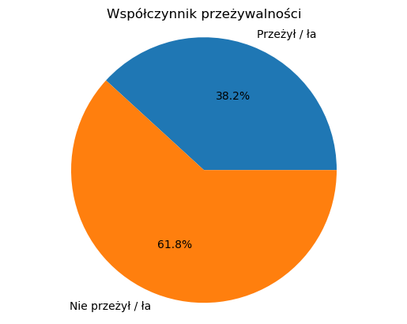

```python
# Sprawdzimy wskaźniki przeżycia w podanym zbiorze danych (ten zbior nie pokazuje wszystkich pasażerów Tytanika)
# Ile przeżyło katastrofę ze zbioru
value_counts = df['survived'].value_counts()
print(value_counts)

# Wizualizujemy to
# Reverse the order to match value_counts
reversed_counts = value_counts[::-1]
# Create a pie chart
plt.pie(reversed_counts, labels=['Przeżył / ła', 'Nie przeżył / ła'], autopct='%1.1f%%')
# Equal aspect ratio ensures that pie is drawn as a circle
plt.axis('equal')
# Show the plot
plt.title('Współczynnik przeżywalności')
plt.show()
```

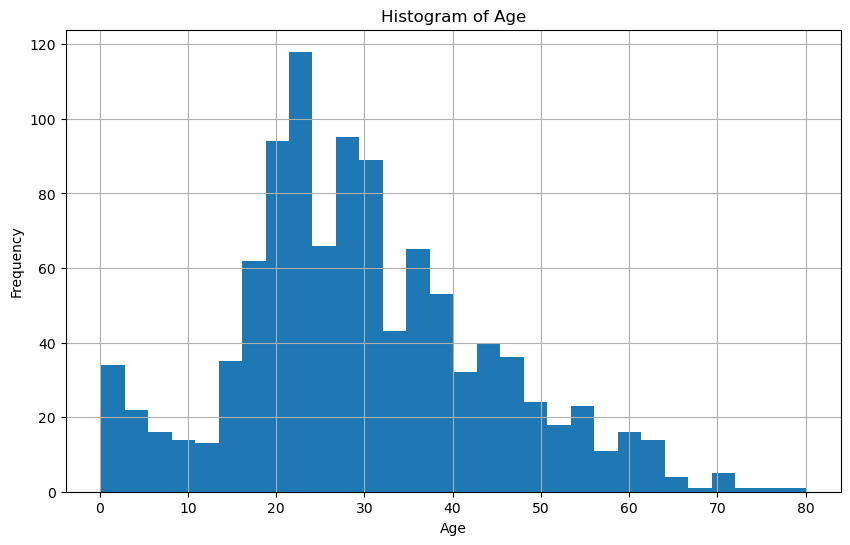

```python
# Zobaczymy ilości pasażerów po wieku tylko dla tych, dane po wieku o których wiemy
# Filter out rows with NaN values in 'Age'
filtered_by_null_age_df = df.dropna(subset=['age'])
filtered_by_null_age_df['age'].hist(bins=30, figsize=(10, 6))  # Increase bins and figure size
plt.title('Histogram of Age')
plt.xlabel('Age')
plt.ylabel('Frequency')
plt.show()
```

```
Ilość pasażerów z wiadomym wiekiem, którzy przeżyłi: 427
```

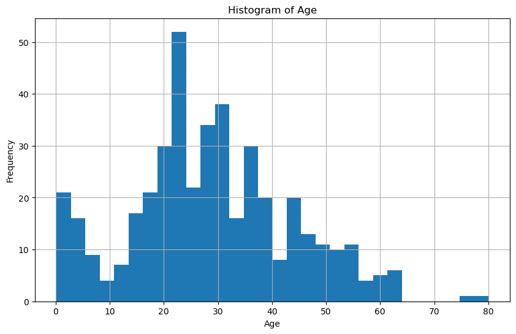

```python
# Zobaczymy ilości pasażerów po wieku i inne analizy dla tych kto przeżył (tylko dla tych, wiek których wiadomy)

survived_df = filtered_by_null_age_df[filtered_by_null_age_df['survived'] == 1.0]
count_with_known_age = len(survived_df)
print(f"Ilość pasażerów z wiadomym wiekiem, którzy przeżyłi: {count_with_known_age}")
print()

survived_df['age'].hist(bins=30, figsize=(10, 6))
plt.title('Histogram of Age')
plt.xlabel('Age')
plt.ylabel('Frequency')
plt.show()
```

```python
# Ile z nich są dzieci, kobiety, mężczyzny (dla tych, wiek których jest wiadomy)
children_survived_df = survived_df[survived_df['age'] < 18]
children_survived_df_count = len(children_survived_df)
print(f"Ilość dzieci, które przeżyły = {children_survived_df_count}")
```

```
Ilość dzieci, które przeżyły = 81
```

```python
men_survived_df = survived_df[(survived_df['age'] >= 18) & (survived_df['sex'] == 'male')]
men_survived_df_count = len(men_survived_df)
print(f"Ilość mężczyzn, którzy przeżyli = {men_survived_df_count}")
```

```
Ilość mężczyzn, którzy przeżyli = 104
```

```python
women_survived_df = survived_df[(survived_df['age'] >= 18) & (survived_df['sex'] == 'female')]
women_survived_df_count = len(women_survived_df)
print(f"Ilość kobiet, które przeżyły = {women_survived_df_count}")
```

```
Ilość kobiet, które przeżyły = 242
```

```
Ilość pasażerów z wiadomym wiekiem, którzy nie przeżyłi: 619
```

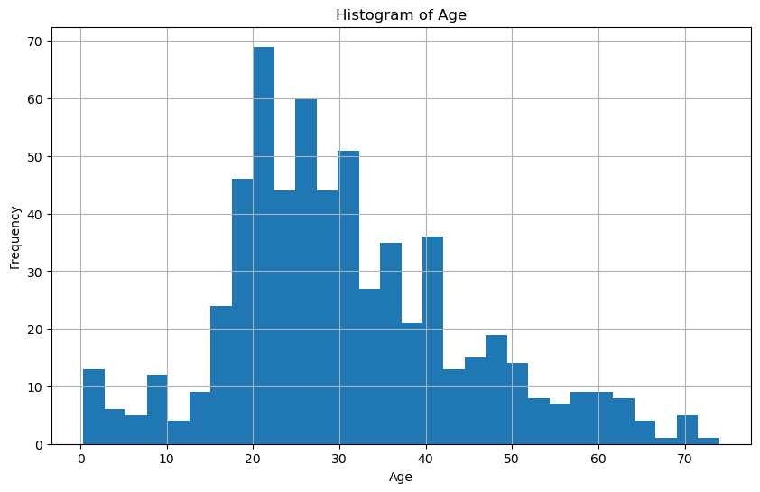

```python
# Wykonujemy to samo dla tych, kto nie przeżył

not_survived_df = filtered_by_null_age_df[filtered_by_null_age_df['survived'] == 0.0]
count_with_known_age = len(not_survived_df)
print(f"Ilość pasażerów z wiadomym wiekiem, którzy nie przeżyłi: {count_with_known_age}")
print()

not_survived_df['age'].hist(bins=30, figsize=(10, 6))
plt.title('Histogram of Age')
plt.xlabel('Age')
plt.ylabel('Frequency')
plt.show()
```

```python
# Ile z nich są dzieci, kobiety, mężczyzny (dla tych, wiek których jest wiadomy)
children_not_survived_df = not_survived_df[not_survived_df['age'] < 18]
children_not_survived_df_count = len(children_not_survived_df)
print(f"Ilość dzieci, które nie przeżyły = {children_not_survived_df_count}")
```

```
Ilość dzieci, które nie przeżyły = 73
```

```python
men_not_survived_df = not_survived_df[(not_survived_df['age'] >= 18) & (not_survived_df['sex'] == 'male')]
men_not_survived_df_count = len(men_not_survived_df)
print(f"Ilość mężczyzn, którzy nie przeżyli = {men_not_survived_df_count}")
```

```
Ilość mężczyzn, którzy nie przeżyli = 472
```

```python
women_not_survived_df = not_survived_df[(not_survived_df['age'] >= 18) & (not_survived_df['sex'] == 'female')]
women_not_survived_df_count = len(women_not_survived_df)
print(f"Ilość kobiet, które nie przeżyły = {women_not_survived_df_count}")
```

```
Ilość kobiet, które nie przeżyły = 74
```

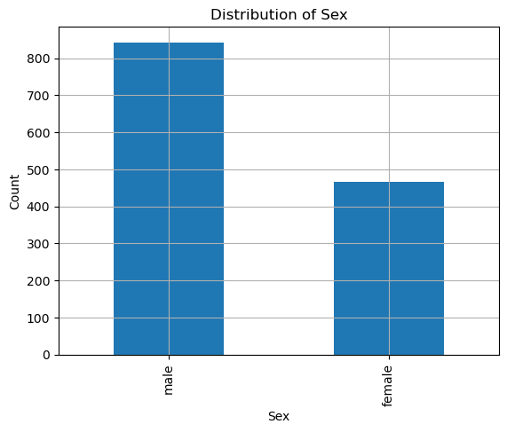

```python
# Histogramy / barcharty po innych danych

# Ile osób męskiego i żeńskiego rodzaju ze wszystkiego zbioru danych
value_counts = df['sex'].value_counts()
value_counts.plot(kind='bar', grid=True)
plt.title('Distribution of Sex')
plt.xlabel('Sex')
plt.ylabel('Count')
plt.show()
```

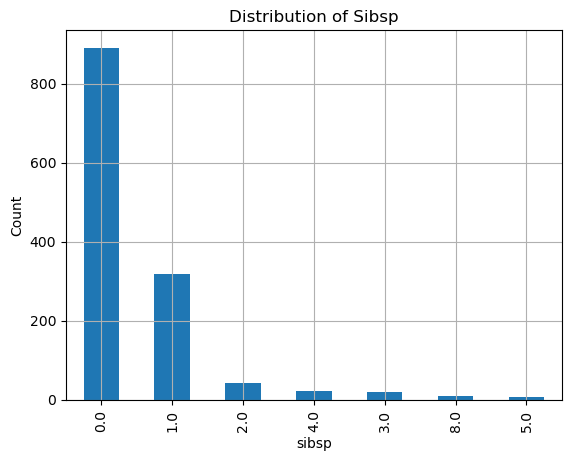

```python
# Liczba rodzeństwa / małżonków na pokładzie
value_counts = df['sibsp'].value_counts()
value_counts.plot(kind='bar', grid=True)
plt.title('Distribution of Sibsp')
plt.xlabel('sibsp')
plt.ylabel('Count')
plt.show()
```

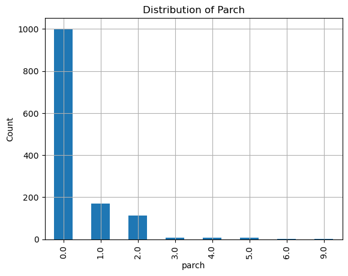

```python
# Liczba rodziców/dzieci na pokładzie
value_counts = df['parch'].value_counts()
value_counts.plot(kind='bar', grid=True)
plt.title('Distribution of Parch')
plt.xlabel('parch')
plt.ylabel('Count')
plt.show()
```

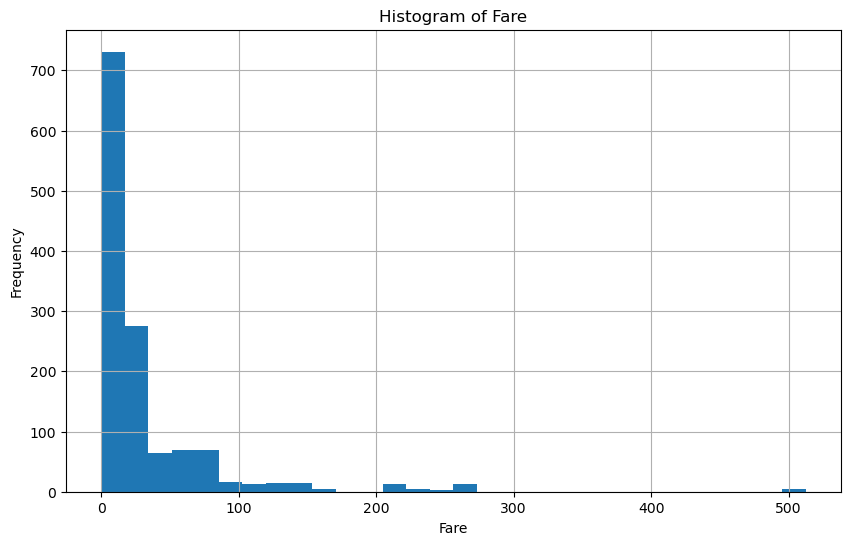

```python
# Cena biletu
df['fare'].hist(bins=30, figsize=(10, 6))
plt.title('Histogram of Fare')
plt.xlabel('Fare')
plt.ylabel('Frequency')
plt.show()
```

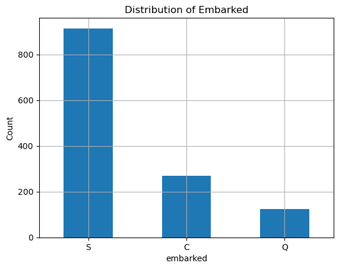

```python
# Port, w którym pasażer wszedł na pokład (C = Cherbourg, Q = Queenstown, S = Southampton)
value_counts = df['embarked'].value_counts()
value_counts.plot(kind='bar', grid=True)
plt.title('Distribution of Embarked')
plt.xlabel('embarked')
plt.ylabel('Count')
plt.xticks(horizontalalignment='center', rotation=0)
plt.show()
```

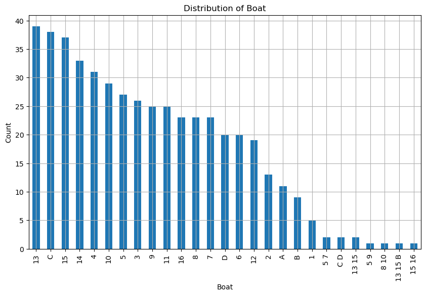

```python
# Numer łodzi ratunkowej (tylko jeśli mamy takie dane)
filtered_by_null_boat_df = df.dropna(subset=['boat'])

value_counts = filtered_by_null_boat_df['boat'].value_counts()
plt.figure(figsize=(10, 6))
value_counts.plot(kind='bar', grid=True)
plt.title('Distribution of Boat')
plt.xlabel('Boat')
plt.ylabel('Count')
plt.xticks(horizontalalignment='center', rotation=90)
plt.show()
```

### 4. Transformacja danych

*Zastąpimy na średnią wartość wiek pasażerów, dla których tych danych brakuje. Natomiast cenę biletu z niewiadomą wartością zastąpimy medyaną (śriednie znaczenie zawiera nie dużą ilość bogatych pasażerów). Dla kolumn 'cabin', 'embarked', 'boat', 'home.dest' zamieniamy None (NaN) na 'Unknown'. Dla 'body' dla komórek o wartości null przypisujemy -1*

```python
# Podmieniamy puste wartości
transformed_df = df.fillna({'age': df['age'].mean(), 'fare' : df['fare'].median(), 'cabin': 'Unknown', 'embarked': 'Unknown', 'boat' : 'Unknown', 'body' : -1, 'home.dest' : 'Unknown'})
```

```python
# Upewniamy się że nie mamy żadnych pustych wartości
transformed_df.isnull().sum()
```

```
pclass       0
survived     0
name         0
sex          0
age          0
sibsp        0
parch        0
ticket       0
fare         0
cabin        0
embarked     0
boat         0
body         0
home.dest    0
dtype: int64
```

*Kontynuujemy analizę z transformed_df*

### 5. Analiza relacji między zmiennymi

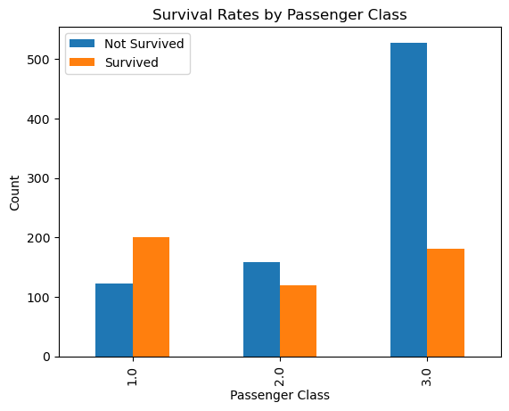

```python
# Zobaczmy jak się zmienia szansa na przeżycie pasażera w załeżności od klasy

# Group by 'pclass' and count the number of survivors and non-survivors
grouped_data = transformed_df.groupby('pclass')['survived'].value_counts().unstack()
# Create a bar chart
grouped_data.plot(kind='bar')
# Customize the chart
plt.title('Survival Rates by Passenger Class')
plt.xlabel('Passenger Class')
plt.ylabel('Count')
plt.legend(['Not Survived', 'Survived'])
plt.show()
```

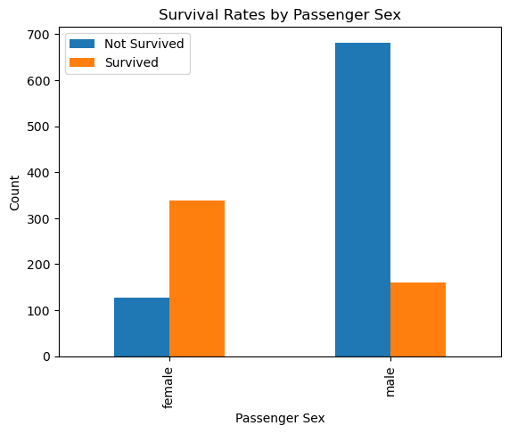

```python
# Jak się zmienia szansa na przeżycie pasażera w załeżności od pleci
grouped_data = transformed_df.groupby('sex')['survived'].value_counts().unstack()
grouped_data.plot(kind='bar')
plt.title('Survival Rates by Passenger Sex')
plt.xlabel('Passenger Sex')
plt.ylabel('Count')
plt.legend(['Not Survived', 'Survived'])
plt.show()
```

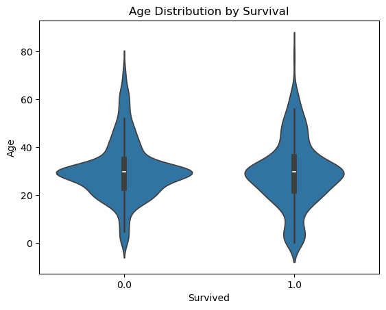

```python
# Jak się zmienia szansa na przeżycie pasażera w załeżności od wieku

# Create a violin plot
sns.violinplot(x='survived', y='age', data=transformed_df)
# Customize the plot
plt.title('Age Distribution by Survival')
plt.xlabel('Survived')
plt.ylabel('Age')
plt.show()
```